# Group 26: Arcene Cancer

Author

Todd Davison, Greta Medlam, Douglas Blackwood, Mariam El Mawed

# 1 Introduction

This file contains code and analysis for the classification of cancerous tissue, based on dimension reduction and various classification methods.

We use the following training and test data sets, that each contain 100 samples of either cancerous or non-cancerous tissue samples.

```r
training <- read.csv("group_26.csv")
test <- read.csv("arcene_test.csv")
```

We look at the dimensions of the test and training sets.

```r
X_train <- as.matrix(training[,-1])
y_train <- as.matrix(training[,1])

X_test <- as.matrix(test[,-1])
y_test <- as.matrix(test[,1])

data.frame(Training_set = dim(X_train),
           Test_set = dim(X_test),
           row.names = c("Observations", "Features")) %>%
  gt(rownames_to_stub = T)
```

|  | Training_set | Test_set |
| --- | --- | --- |
| Observations | 100 | 100 |
| Features | 2506 | 9920 |

There are 2506 features and 100 observations in the training set. We look at the split of cancerous to non-cancerous observations.

```r
cancerous <- training[training$Class == 1,]
dim(cancerous)
```

```
[1]   44 2507
```

So we have 44 cancerous tissue samples and 56 non-cancerous samples.

We will now check if the variables are on the same scale.

```r
# standard deviations of variables
sds <- apply(X_train, 2, sd, na.rm = TRUE)
summary(sds)
```

```
   Min. 1st Qu.  Median    Mean 3rd Qu.    Max.
   0.10   22.16   40.74   59.33   82.70  316.23
```

There is a large difference between the min and max, so we look at a boxplot.

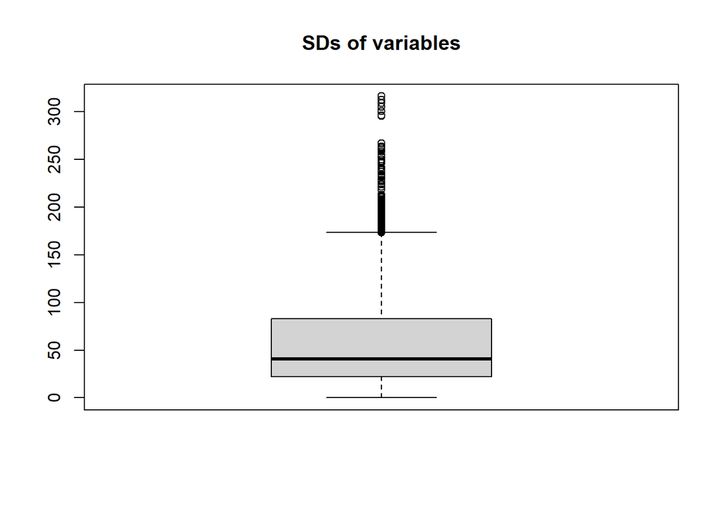

```r
boxplot(sds, main = "SDs of variables")
```

## 1.1 Dimension Reduction

```r
pca_fit <- prcomp(X_train, cor = T)
pca_summary <- summary(pca_fit)
pca_summary$importance[, 1:20]
```

```
                              PC1        PC2       PC3       PC4       PC5
Standard deviation     2667.81583 1883.39730 928.38815 693.89320 621.87633
Proportion of Variance    0.45177    0.22516   0.05471   0.03056   0.02455
Cumulative Proportion     0.45177    0.67693   0.73164   0.76220   0.78675
                             PC6       PC7       PC8       PC9      PC10
Standard deviation     557.23643 544.05417 446.21754 412.04872 390.92122
Proportion of Variance   0.01971   0.01879   0.01264   0.01078   0.00970
Cumulative Proportion    0.80646   0.82525   0.83789   0.84866   0.85836
                            PC11      PC12      PC13      PC14      PC15
Standard deviation     352.54071 337.15851 317.49151 298.35759 286.19193
Proportion of Variance   0.00789   0.00722   0.00640   0.00565   0.00520
Cumulative Proportion    0.86625   0.87347   0.87987   0.88552   0.89072
                            PC16      PC17      PC18      PC19      PC20
Standard deviation     272.15265 260.30839 255.42957 236.19969 230.11926
Proportion of Variance   0.00470   0.00430   0.00414   0.00354   0.00336
Cumulative Proportion    0.89542   0.89972   0.90386   0.90740   0.91076
```

From this we can see the first 6 principal components (PCs) explain 80% of the variability, and 18 explains 90% of the variability.

Since 18 PCs explain 90% of the variability, we will proceed with those ones.

```r
#Select/Choose the first 18 pcs which explains 90% of the variation

k <- 18   # number of PCs you decided to keep

X_train_pca <- pca_fit$x[, 1:k]

# Test PCA scores
X_test_pca <- predict(pca_fit, newdata = X_test)[, 1:k]
```

Now this new X_train_pca and _train will be used to train the classification models and test them using X_test_pca and y_test.